# Titanic Exploratory Data Analysis

Richard Pham

February 13, 2018

### Data Dictionary

#### Variable Definition Key

survival Survival 0 = No, 1 = Yes  
pclass Ticket class 1 = 1st, 2 = 2nd, 3 = 3rd  
sex Sex  
Age Age in years  
sibsp # of siblings / spouses aboard the Titanic  
parch # of parents / children aboard the Titanic  
ticket Ticket number  
fare Passenger fare  
cabin Cabin number  
embarked Port of Embarkation C = Cherbourg, Q = Queenstown, S = Southampton

#### Variable Notes

pclass: A proxy for socio-economic status (SES)  
1st = Upper  
2nd = Middle  
3rd = Lower

age: Age is fractional if less than 1. If the age is estimated, is it in the form of xx.5

sibsp: The dataset defines family relations in this way…  
Sibling = brother, sister, stepbrother, stepsister  
Spouse = husband, wife (mistresses and fiancÃ©s were ignored)

parch: The dataset defines family relations in this way…  
Parent = mother, father  
Child = daughter, son, stepdaughter, stepson  
Some children travelled only with a nanny, therefore parch=0 for them.

#### Initial Visualizations

These initial graphs are to get a sense of the data.

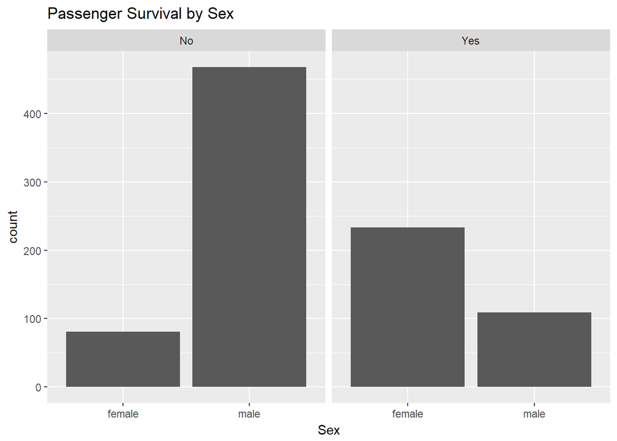

```r
ggplot(data = passenger_df, aes(x = Sex)) +
  geom_histogram(stat = 'count') +
  ggtitle("Passenger Survival by Sex") +
  facet_wrap(~ Survived.qual, ncol = 2)
```

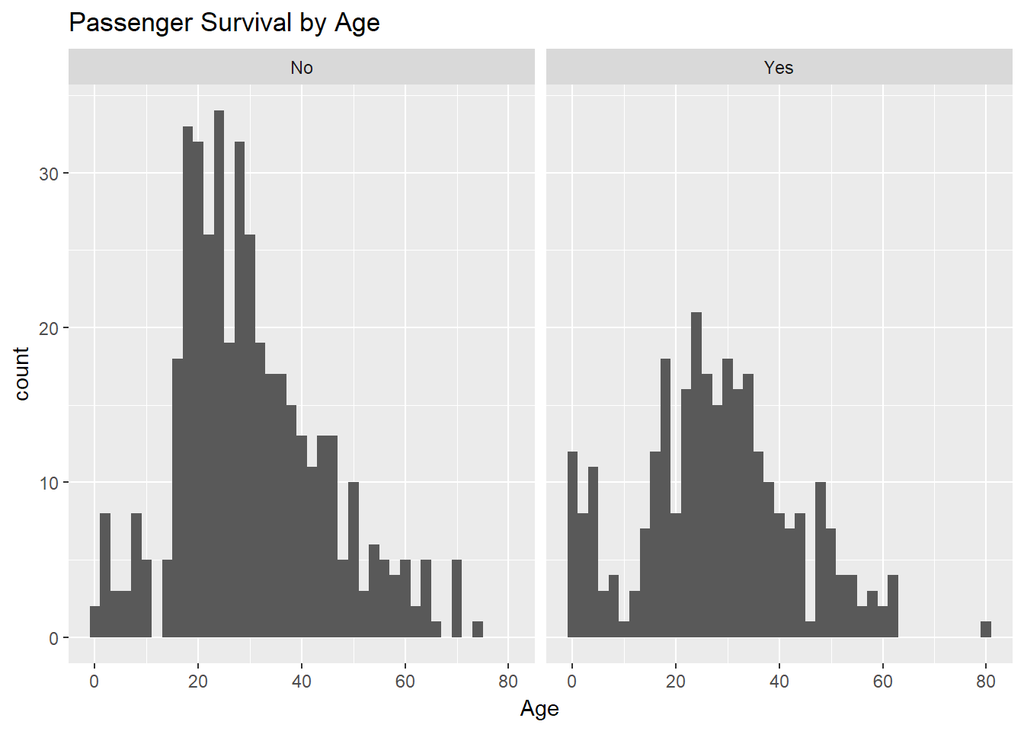

```r
ggplot(data = passenger_df, aes(x = Age)) +
  geom_histogram(binwidth = 2) +
  ggtitle("Passenger Survival by Age") +
  facet_wrap(~ Survived.qual, ncol = 2)
```

Notes:  
Passengers between 20 and 40 were more likely to die. The height of the bins in the No survival graph is much higher relative to the Yes survival graph.

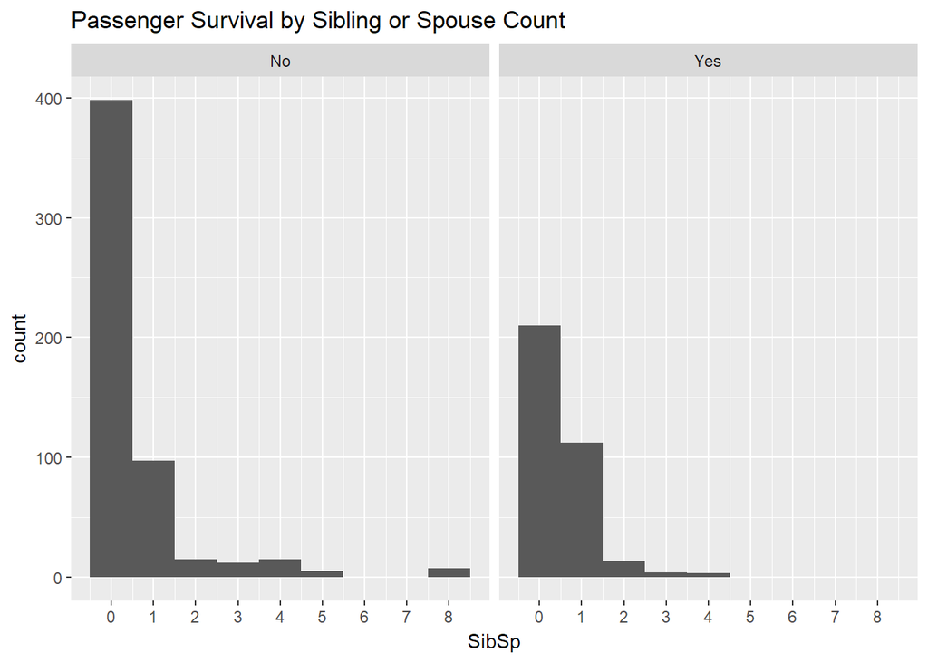

```r
ggplot(data = passenger_df, aes(x = SibSp)) +
  geom_histogram(binwidth = 1) +
  scale_x_continuous(breaks = seq(0, 8, 1)) +
  ggtitle("Passenger Survival by Sibling or Spouse Count") +
  facet_wrap(~ Survived.qual, ncol = 2)
```

Notes:  
People with no siblings or spouses on board were more likely to die. However, it may not matter how many a person has so much as if they have any siblings or spouses at all. It may be more useful to make this a binary value for prediction.

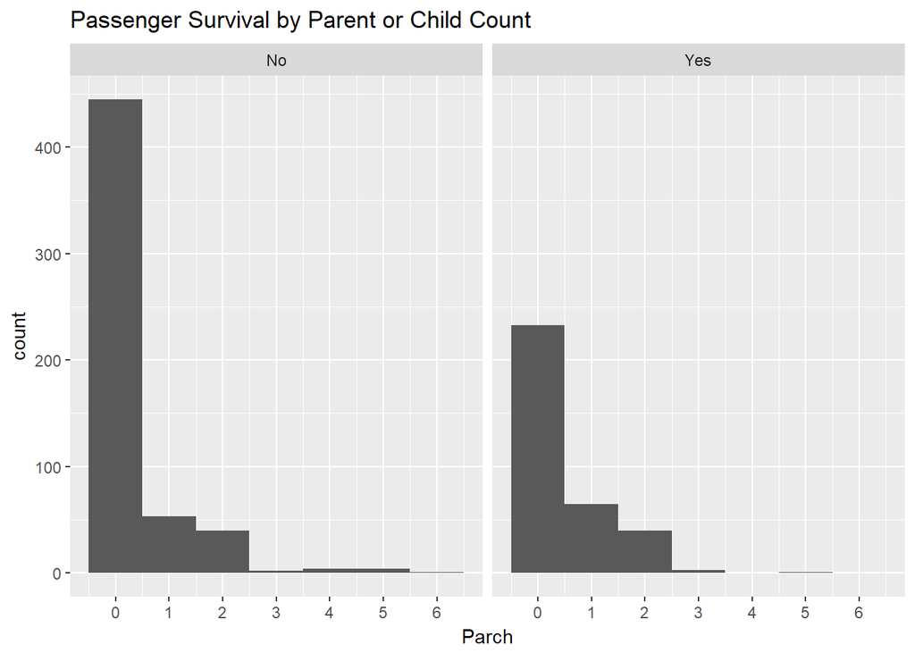

```r
ggplot(data = passenger_df, aes(x = Parch)) +
  geom_histogram(binwidth = 1) +
  scale_x_continuous(breaks = seq(0, 8, 1)) +
  ggtitle("Passenger Survival by Parent or Child Count") +
  facet_wrap(~ Survived.qual, ncol = 2)
```

Notes:  
Similar case to the sibling spouse variable.

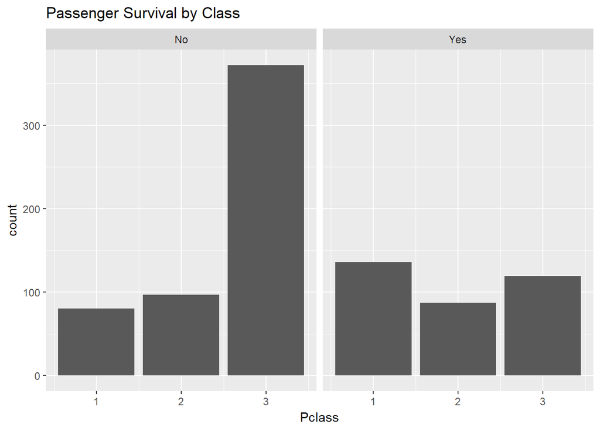

```r
ggplot(data = passenger_df, aes(x = Pclass)) +
  geom_histogram(stat = 'count') +
  ggtitle("Passenger Survival by Class") +
  facet_wrap(~ Survived.qual, ncol = 2)
```

Notes: Passengers in 3rd class were much less likely to survive.

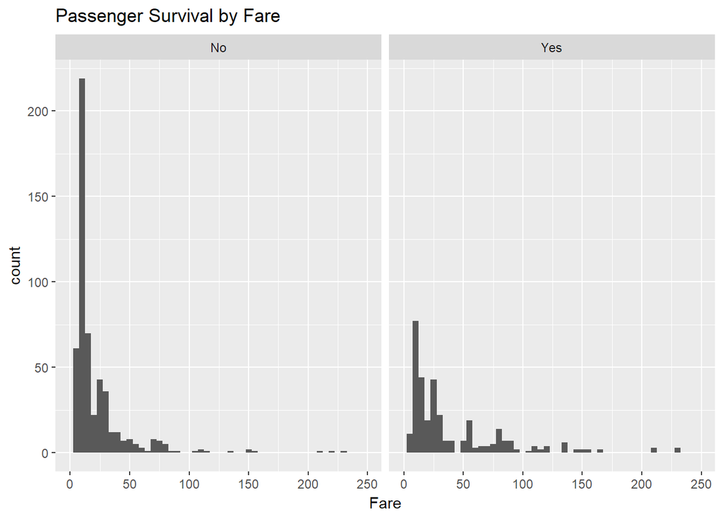

```r
ggplot(data = passenger_df, aes(x = Fare)) +
  geom_histogram(binwidth = 5) +
  scale_x_continuous(lim = c(0, quantile(passenger_df$Fare, 0.99))) +
  ggtitle("Passenger Survival by Fare") +
  facet_wrap(~ Survived.qual, ncol = 2)
```

Notes: Passengers with a fare less than $10 were less likely to survive. It may be better to encode social class in one variable for prediction rather than use both Pclass and Fare.

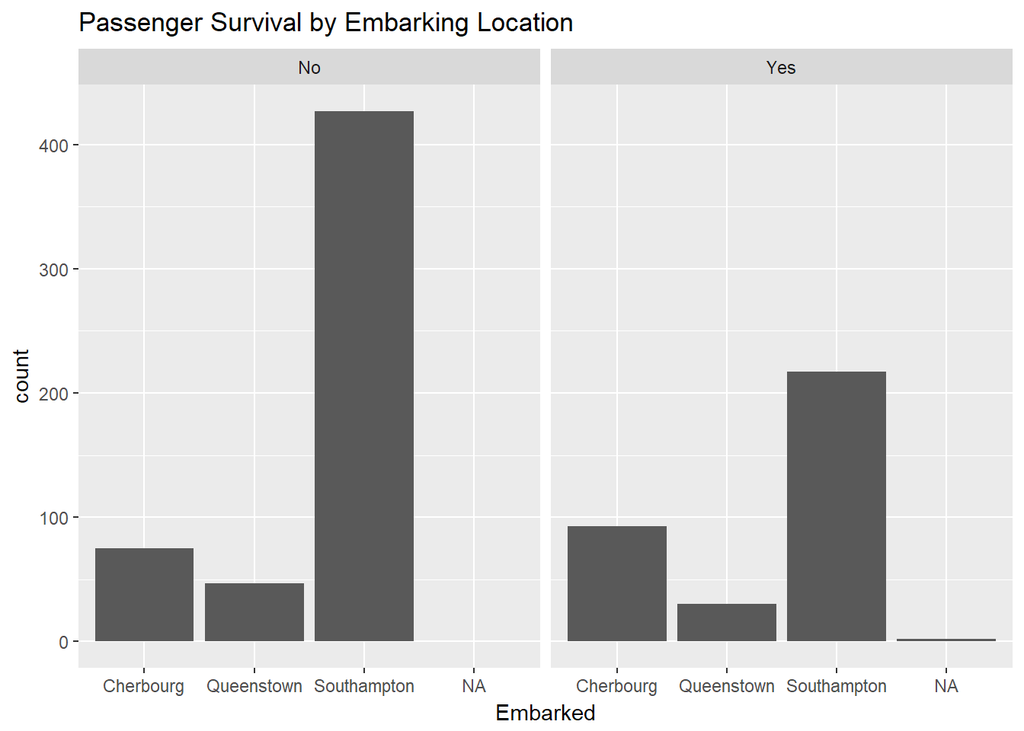

```r
ggplot(data = passenger_df, aes(x = Embarked)) +
  geom_histogram(stat = 'count') +
  ggtitle("Passenger Survival by Embarking Location") +
  facet_wrap(~ Survived.qual, ncol = 2)
```

Notes:  
Passengers embarking from Southampton were less likely to survive. Is it possible that class is being geographically encoded?

##### Remaining variables

The cabin and ticket number data will be left unused for now. Though cabin number may be useful, many passengers do not have this data available. It may be possible to extract further relations from ticket number order, such as consecutive ticket numbers being near the same room or close friends. It would also be interesting to vectorize the names of the passengers in an attempt extrapolate more features, possibly social class or ethnicity.

#### Investigating Social Class Further

A graph containing all of the social class information.

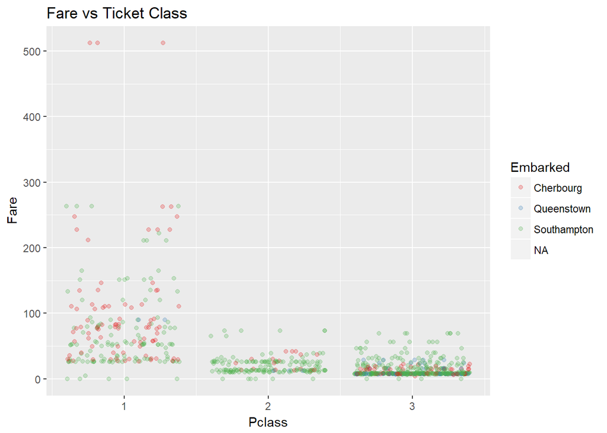

```r
ggplot(data = passenger_df, aes(x = Pclass, y = Fare, color = Embarked)) +
  geom_point(alpha = 0.25, position = position_jitter(h = 0)) +
  scale_color_brewer(type = "qual", palette = 'Set1') +
  ggtitle("Fare vs Ticket Class")
```

Notes: This is unexpected. The ticket class does not bin the fares into three perfect groups. These variables are not redundant.

Let’s remove embarking location to see survival.

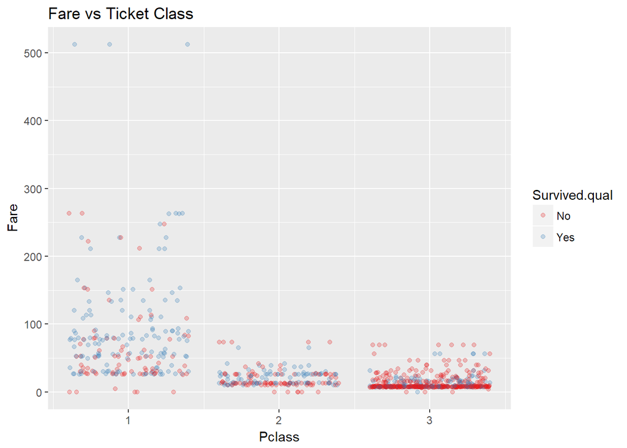

```r
ggplot(data = passenger_df, aes(x = Pclass, y = Fare, color = Survived.qual)) +
  geom_point(alpha = 0.25, position = position_jitter(h = 0)) +
  scale_x_continuous(breaks = seq(1, 3, 1)) +
  scale_color_brewer(type = "qual", palette = 'Set1') +
  ggtitle("Fare vs Ticket Class")
```

Let’s remove class to see survival.

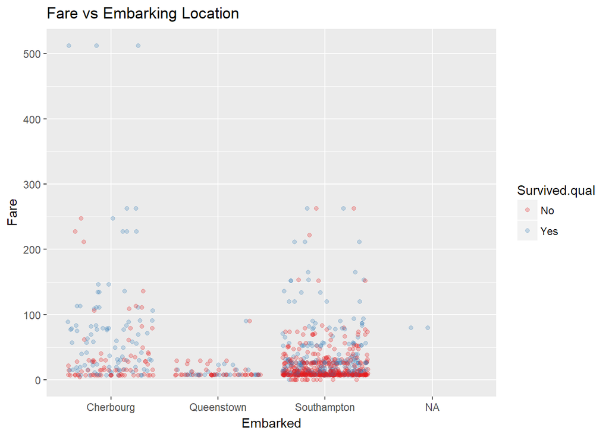

```r
ggplot(data = passenger_df, aes(x = Embarked, y = Fare, color = Survived.qual)) +
  geom_point(alpha = 0.25, position = position_jitter(h = 0)) +
  scale_color_brewer(type = "qual", palette = 'Set1') +
  ggtitle("Fare vs Embarking Location")
```

```r
passenger_df[62, 'Embarked'] = 'Cherbourg'
passenger_df[830, 'Embarked'] = 'Cherbourg'
```

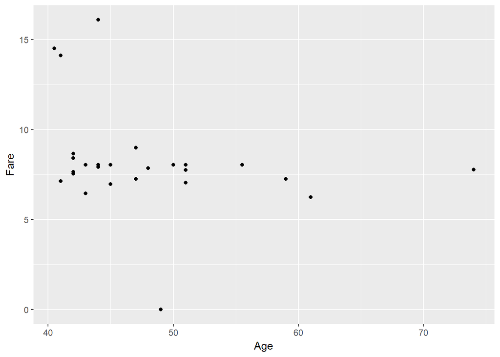

```r
ggplot(data = passenger_df[passenger_df$Pclass == 3 &
                             passenger_df$Embarked == 'Southampton' &
                             passenger_df$Sex == 'male' &
                             passenger_df$Age > 40,],
       aes(x = Age, y = Fare)) +
  geom_point()
```

```r
test_df[153, 'Fare'] <- mean(passenger_df$Fare[passenger_df$Pclass == 3 &
                                                 passenger_df$Embarked == 'Southampton' &
                                                 passenger_df$Sex == 'male' &
                                                 passenger_df$Age > 40],
                             na.rm=TRUE)
```

In the test data, I imputed Mr. Thomas Storey’s Fare price as 8.221144.

Python cannot take NA as a training value. The missing ages in the training and test data either need to be computed or assigned a value.

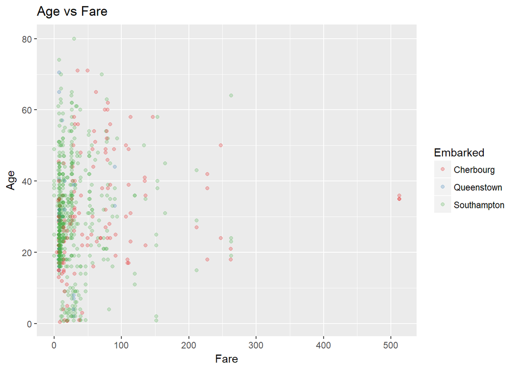

```r
ggplot(data = passenger_df, aes(x = Fare, y = Age, color = Embarked)) +
  geom_point(alpha = 0.25) +
  scale_color_brewer(type = "qual", palette = 'Set1') +
  ggtitle("Age vs Fare")
```

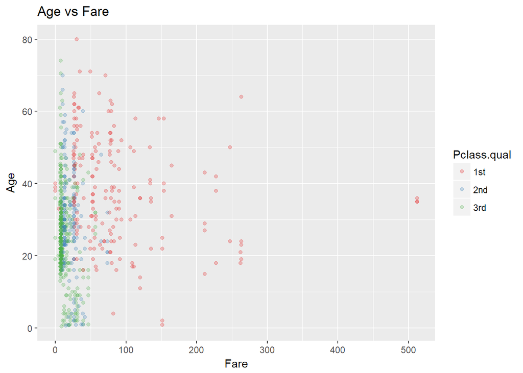

```r
ggplot(data = passenger_df, aes(x = Fare, y = Age, color = Pclass.qual)) +
  geom_point(alpha = 0.25) +
  scale_color_brewer(type = "qual", palette = 'Set1') +
  ggtitle("Age vs Fare")
```

Notes: Unfortunately, there seems to be no major patterns between the Age and the other variables.

It is possible the missing Age values all come from one Fare range, Embarking location, or ticket class.

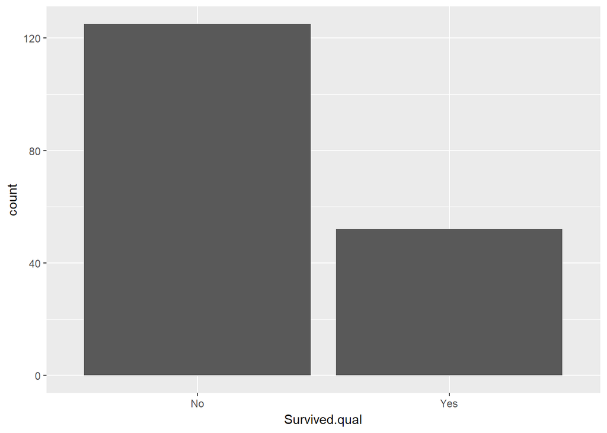

```r
ggplot(data = subset(passenger_df, is.na(passenger_df$Age)),
       aes(x = Survived.qual)) +
  geom_histogram(stat = 'count')
```

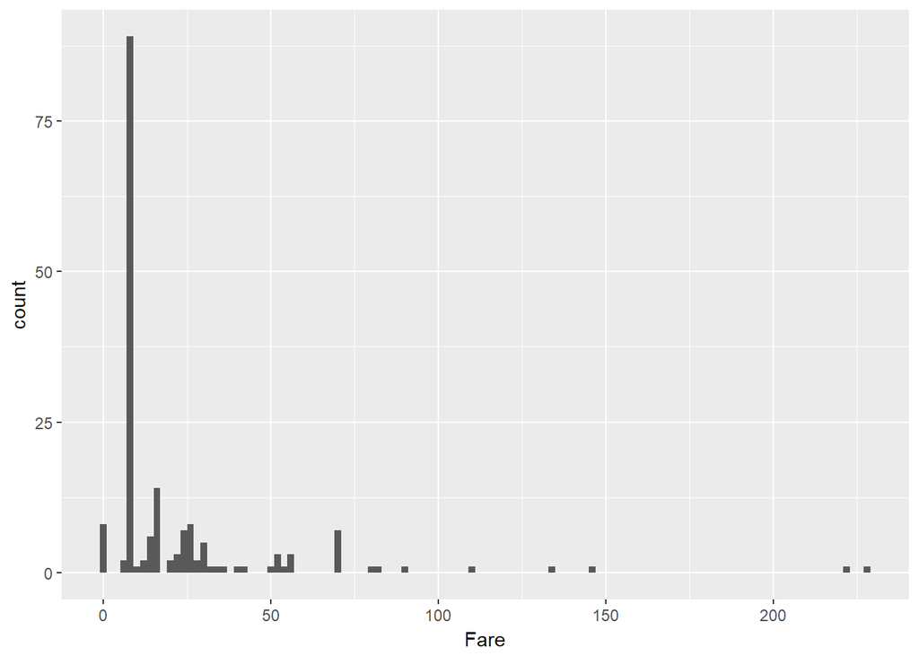

```r
ggplot(data = subset(passenger_df, is.na(passenger_df$Age)),
       aes(x = Fare)) +
  geom_histogram(binwidth = 2)
```

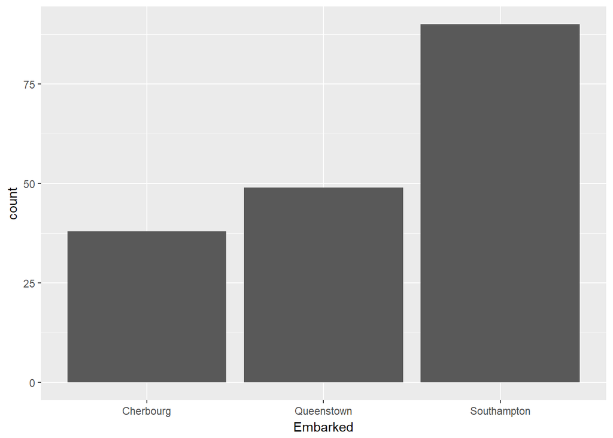

```r
ggplot(data = subset(passenger_df, is.na(passenger_df$Age)),
       aes(x = Embarked)) +
  geom_histogram(stat = 'count')
```

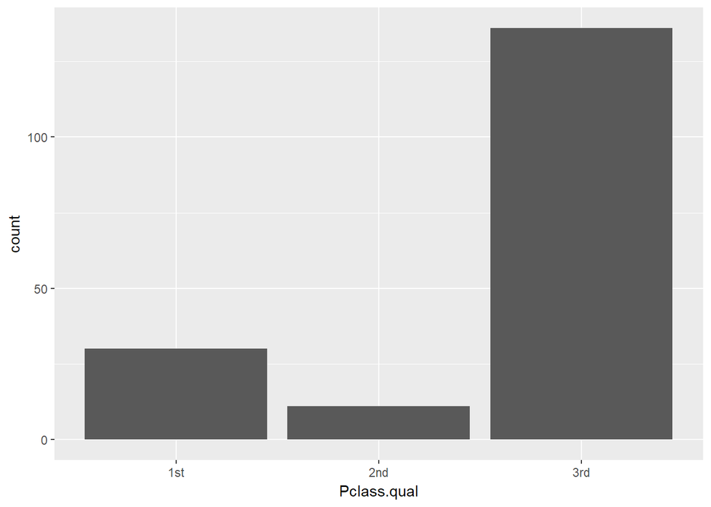

```r
ggplot(data = subset(passenger_df, is.na(passenger_df$Age)),
       aes(x = Pclass.qual)) +
  geom_histogram(stat = 'count')
```

#### Strategies for Re-encoding Data for Machine Learning Toolbox in Python

1. Encode embarking location as a dummy variable. It does not make sense to give them values such as 1, 2, and 3 since the average of Cherbourg and Southampton is not Queenstown.
2. Impute missing Age values as a constant far over real age values. For a supervised classifier such as a decision tree, this should create a separate branch for those over the age of 200 (or some other large number.)
3. Create a separate classifier for those missing Age data and combine the results.

Do strategy 1 in R. 2 and 3 are more easily done in Python.

```r
passenger_df$C <- ifelse(passenger_df$Embarked == 'Cherbourg', 1, 0)
passenger_df$Q <- ifelse(passenger_df$Embarked == 'Queenstown', 1, 0)
passenger_df$S <- ifelse(passenger_df$Embarked == 'Southampton', 1, 0)

passenger_df <- mutate(passenger_df, Embarked = case_when(Embarked == 'Cherbourg' ~ 'C',
                                                          Embarked == 'Queenstown' ~ 'Q',
                                                          Embarked == 'Southampton' ~ 'S'))

keeps  <- c('PassengerId', 'Survived', 'Pclass', 'Name', 'Sex', 'Age', 'SibSp', 'Parch', 'Ticket', 'Fare', 'Cabin',
            'Embarked', 'C', 'Q', 'S')
cleaned_train_df <- passenger_df[keeps]
```

```r
test_df$C <- ifelse(test_df$Embarked == 'C', 1, 0)
test_df$Q <- ifelse(test_df$Embarked == 'Q', 1, 0)
test_df$S <- ifelse(test_df$Embarked == 'S', 1, 0)

cleaned_test_df <- test_df[keeps]
```

#### Save the Data for Processing in Python

```r
#write.csv(cleaned_train_df, file = "train_cleaned.csv")
#write.csv(cleaned_test_df, file = "test_cleaned.csv")
```

#### Score Comparison

```r
score_df <- read.csv('titanic-publicleaderboard.csv')
# Forum discussion claims scores greater than 0.85 are a result of cheating
score_df <- score_df[score_df$Score < 0.85,]
quantile(score_df$Score, c(0.25, 0.50, 0.80, 0.90, 0.95))
```

```
##     25%     50%     80%     90%     95%
## 0.75119 0.77033 0.78947 0.79904 0.80382
```